# Predicting Housing Prices

## 4.4 Predicted Prices as a Function of Observed Prices

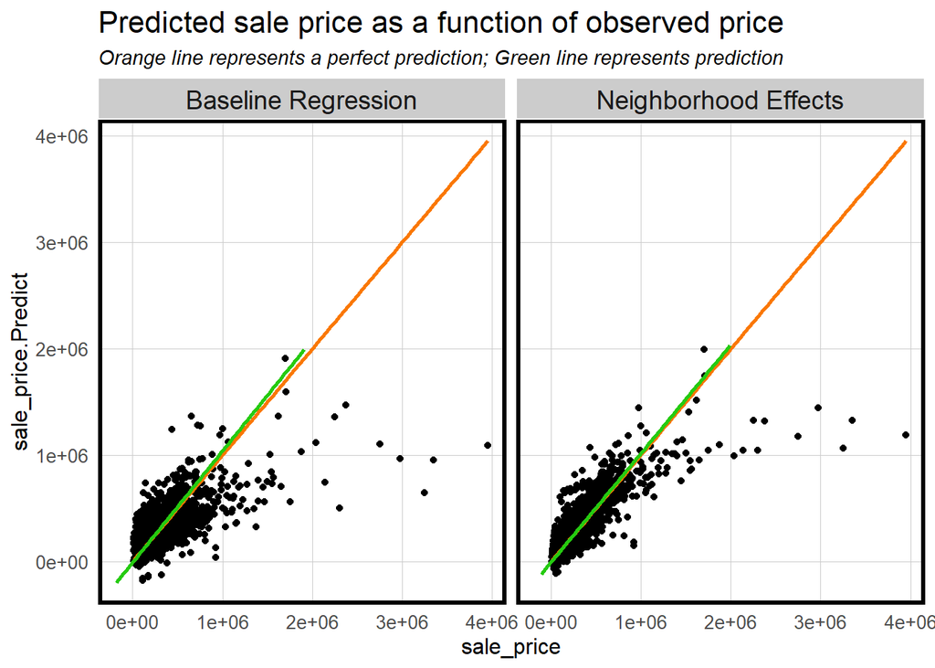

```r
bothRegressions %>%
  dplyr::select(sale_price.Predict, sale_price, Regression) %>%
    ggplot(aes(sale_price, sale_price.Predict)) +
  geom_point() +
  stat_smooth(aes(sale_price, sale_price),
             method = "lm", se = FALSE, size = 1, colour="#FA7800") +
  stat_smooth(aes(sale_price.Predict, sale_price),
              method = "lm", se = FALSE, size = 1, colour="#25CB10") +
  facet_wrap(~Regression) +
  labs(title="Predicted sale price as a function of observed price",
       subtitle="Orange line represents a perfect prediction; Green line represents prediction") +
  plotTheme()
```

This plot illustrates the relationship between the predicted sale prices and the actual observed prices. The distribution of data points predominantly hugging the orange line suggests that the model’s predictions are generally accurate. The green line in the model closely aligns with the orange line, further indicating the precision of the predictions. However, there are regions where the green line diverges from the orange line, pointing to potential inaccuracies in predictions for those areas. Moreover, a few outliers, distant from both the green and orange lines, highlight specific areas where the model might be less reliable.

## 4.5 Map of Residuals for Test set

### 4.5.1 Plot of the Spatial Lag in Errors

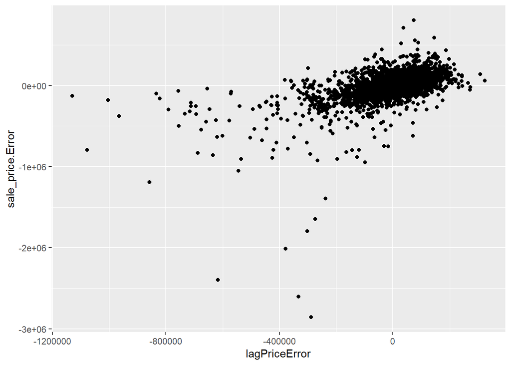

From the plot, we observe a relationship between the prediction errors (sale_price.Error) and the spatial lag of these errors (lagPriceError). The spatial lag error essentially captures the relationship between a point’s prediction error and the average prediction error of its neighboring points. While the majority of data points cluster around the central area, suggesting that most predictions and their spatial lag errors are relatively small, there are some outliers distant from this cluster. This disparity could indicate larger prediction discrepancies in certain geographical locations compared to their surrounding areas. Such spatial distribution hints that the model might not have fully accounted for some geographical or neighboring factors. For instance, a unique environmental or economic characteristic in a specific area may result in significant price differences from its surrounding regions in PA, which the model might have overlooked, leading to these prediction errors.

### 4.5.2 Moran’s I Test Result

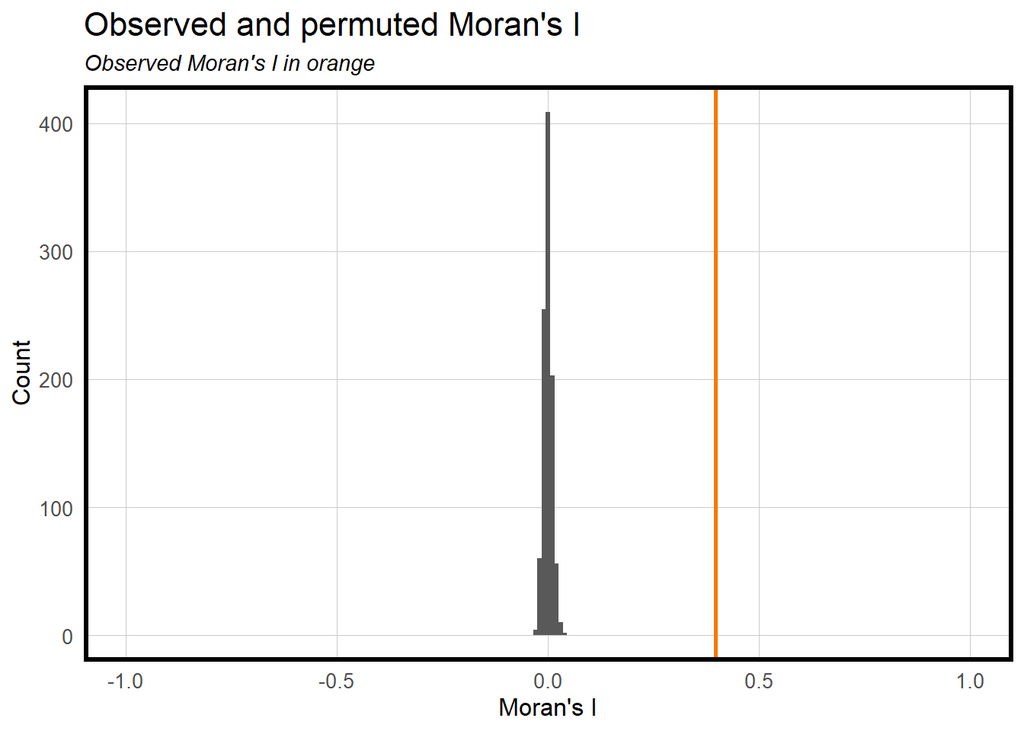

```r
moranTest <- moran.mc(PA.test$sale_price.Error,
                      spatialWeights.test, nsim = 999)

ggplot(as.data.frame(moranTest$res[c(1:999)]), aes(moranTest$res[c(1:999)])) +
  geom_histogram(binwidth = 0.01) +
  geom_vline(aes(xintercept = moranTest$statistic), colour = "#FA7800",size=1) +
  scale_x_continuous(limits = c(-1, 1)) +
  labs(title="Observed and permuted Moran's I",
       subtitle= "Observed Moran's I in orange",
       x="Moran's I",
       y="Count") +
  plotTheme()
```

This test plot depicts the observed Moran’s I value, indicated by the orange line, in relation to the distribution of Moran’s I values obtained from random permutations. As seen from the chart, most of the random Moran’s I values cluster around 0, while the observed Moran’s I value, marked by the orange line, is noticeably shifted to the right. This suggests a certain positive spatial autocorrelation in the model’s errors, indicating that adjacent areas exhibit similar modeling errors.

## 4.6 A Map of Predicted Values

```r
nearest_commercial <- st_nearest_feature(PA.sf, commercial.sf)
closest_distances <- numeric(length(PA.sf))

PA.sf$closest_distance_to_commercial <- NA


for (i in 1:nrow(PA.sf)) {
  distances <- st_distance(PA.sf[i, ], commercial.sf)
  min_distance <- min(distances, na.rm = TRUE)
  PA.sf$closest_distance_to_commercial[i] <- min_distance
}
```

```r
mean_area <- mean(PA.sf$total_livable_area, na.rm = TRUE)
PA.sf <- PA.sf %>%
  mutate(total_livable_area = ifelse(total_livable_area == 0, mean_area, total_livable_area))

mean_bathrm <- mean(PA.sf$number_of_bathrooms, na.rm = TRUE)
PA.sf <- PA.sf %>%
  mutate(number_of_bathrooms = ifelse(number_of_bathrooms == 0 | is.na(number_of_bathrooms), mean_bathrm, number_of_bathrooms))


mean_distance <- mean(PA.sf$closest_distance_to_commercial, na.rm = TRUE)
PA.sf <- PA.sf %>%
  mutate(closest_distance_to_commercial = ifelse(closest_distance_to_commercial == 0 | is.na(closest_distance_to_commercial), mean_distance, closest_distance_to_commercial))


PA.sf$interior_condition <- ifelse(PA.sf$interior_condition == 0, 1, PA.sf$interior_condition)

PA.sf <- PA.sf %>%
  mutate(Age = 2023 - year_built)
PA.sf$Age <- ifelse(PA.sf$Age == -1, 0, PA.sf$Age)

mean_depth <- mean(PA.sf$depth, na.rm = TRUE)
PA.sf$depth[is.na(PA.sf$depth)] <- mean_depth

PA.sf$quality <- ifelse(PA.sf$quality_grade == "A+", 14,
                ifelse(PA.sf$quality_grade == "A ", 13,
                ifelse(PA.sf$quality_grade == "A-", 12,
                ifelse(PA.sf$quality_grade == "B+", 11,
                ifelse(PA.sf$quality_grade == "B ", 10,
                ifelse(PA.sf$quality_grade == "B-", 9,
                ifelse(PA.sf$quality_grade == "C+", 8,
                ifelse(PA.sf$quality_grade == "C ", 7,
                ifelse(PA.sf$quality_grade == "C-", 6,
                ifelse(PA.sf$quality_grade == "D+", 5,
                ifelse(PA.sf$quality_grade == "D ", 4,
                ifelse(PA.sf$quality_grade == "D-", 3,
                ifelse(PA.sf$quality_grade == "E+", 2,
                ifelse(PA.sf$quality_grade == "E ", 1,
                ifelse(PA.sf$quality_grade == "E-", 0,
                ifelse(PA.sf$quality_grade == "2 ", 2,
                ifelse(PA.sf$quality_grade == "3 ", 3,
                ifelse(PA.sf$quality_grade == "4 ", 4,
                ifelse(PA.sf$quality_grade == "5 ", 5,
                ifelse(PA.sf$quality_grade == "6 ", 6, NA_real_))))))))))))))))))))
PA.sf$quality <- ifelse(PA.sf$quality == 0, 1, PA.sf$quality)
```

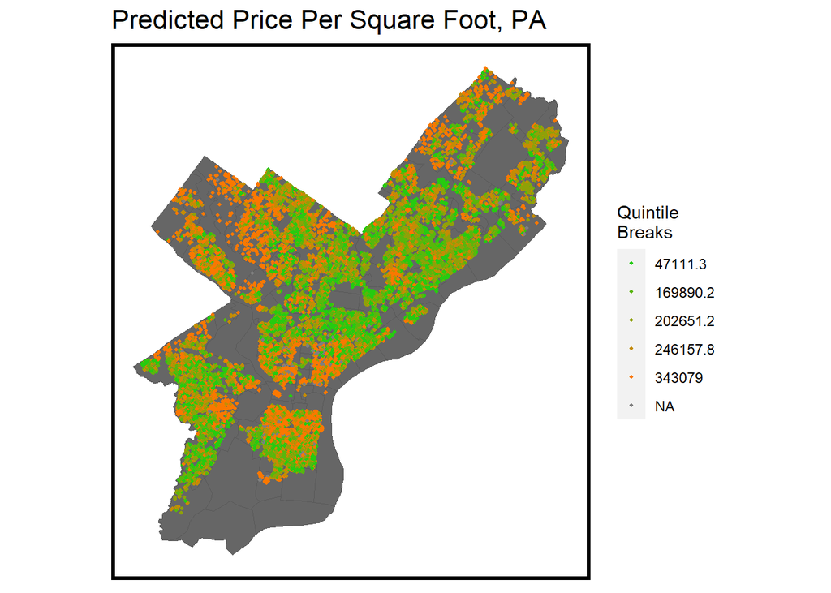

```r
PA_predict <- PA.sf[PA.sf$toPredict %in% c("MODELLING", "CHALLENGE"), ]

predicted_values <- predict(model, newdata = PA_predict)
PA_predict$predicted_sale_price <- predicted_values

ggplot() +
  geom_sf(data = PAnhoods, fill = "grey40") +
  geom_sf(data = PA_predict, aes(colour = q5(predicted_sale_price)),
          show.legend = "point", size = .75) +
  scale_colour_manual(values = palette5,
                   labels=qBr(PA_predict,"predicted_sale_price"),
                   name="Quintile\nBreaks") +
  labs(title="Predicted Price Per Square Foot, PA") +
  mapTheme()
```

```r
Challenge_results <- PA_predict %>% filter(toPredict == "CHALLENGE")

selected_data <- PA_predict%>% select(sale_price, predicted_sale_price)
neg <- PA_predict %>% filter(predicted_sale_price < 0)
```

## 4.7 A Map of Mean Absolute Percentage Error (MAPE) by Neighborhood

## Predictions by neighborhood

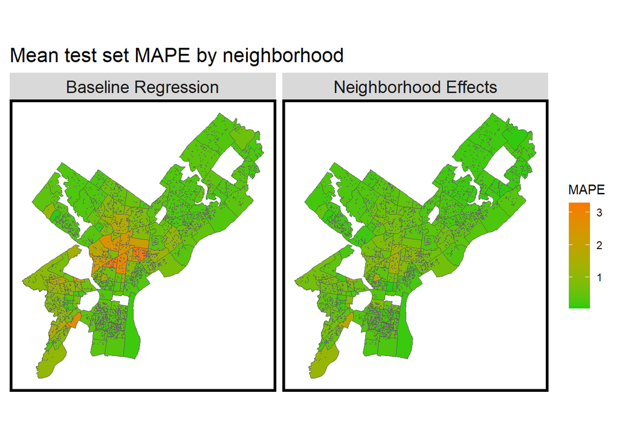

```r
st_drop_geometry(bothRegressions) %>%
  group_by(Regression, name) %>%
  summarize(mean.MAPE = mean(sale_price.APE, na.rm = T)) %>%
  ungroup() %>%
  left_join(PAnhoods, by = c("name" = "name")) %>%
    st_sf() %>%
    ggplot() +
      geom_sf(aes(fill = mean.MAPE)) +
      geom_sf(data = bothRegressions, colour = "grey40", size = .05) +
      facet_wrap(~Regression) +
      scale_fill_gradient(low = palette5[1], high = palette5[5],
                          name = "MAPE") +
      labs(title = "Mean test set MAPE by neighborhood") +
      mapTheme()
```

In the “Baseline Regression” map, we observe that while a majority of the regions are shaded in green, indicating a lower prediction error, there are still several areas, particularly in the central regions, that are colored in orange or red. This denotes that these specific areas have relatively larger prediction errors. On the other hand, The “Neighborhood Effects” map provides a visualization of the MAPE values across different neighborhoods when predicting housing prices.In the “Neighborhood Effects” map, the distribution of prediction errors appears more uniform, with most of the regions being shaded green. This suggests that by incorporating neighborhood effects, the model’s predictive performance has been enhanced.

## 4.8 Scatterplot plot of MAPE by Nhood as a function of mean price by Nhood

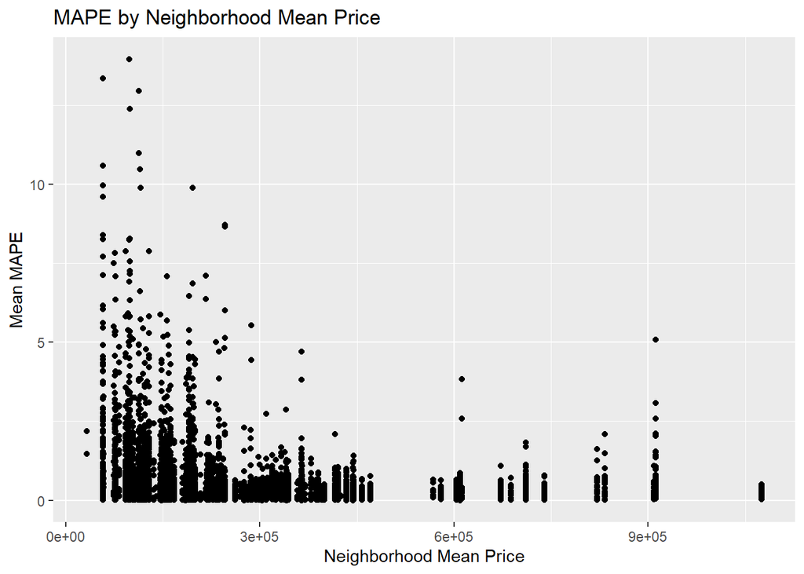

```r
PA_test_df <- st_drop_geometry(PA.test)
bothRegressions_df <- st_drop_geometry(bothRegressions)


neighborhood_data <- merge(PA_test_df %>% select(name, sale_price),
                           bothRegressions_df %>% select(name, sale_price.APE),
                           by = "name")

neighborhood_mean_price <- neighborhood_data %>%
  group_by(name) %>%
  summarize(mean_price = mean(sale_price, na.rm = TRUE))

neighborhood_data <- merge(neighborhood_mean_price, neighborhood_data, by = "name")

ggplot(neighborhood_data, aes(x = mean_price, y = sale_price.APE)) +
  geom_point() +
  labs(x = "Neighborhood Mean Price", y = "Mean MAPE") +
  ggtitle("MAPE by Neighborhood Mean Price")
```